# Creating reproducible and parameterized reports with RMarkdown

2022-11-10

## Let’s step back in time …

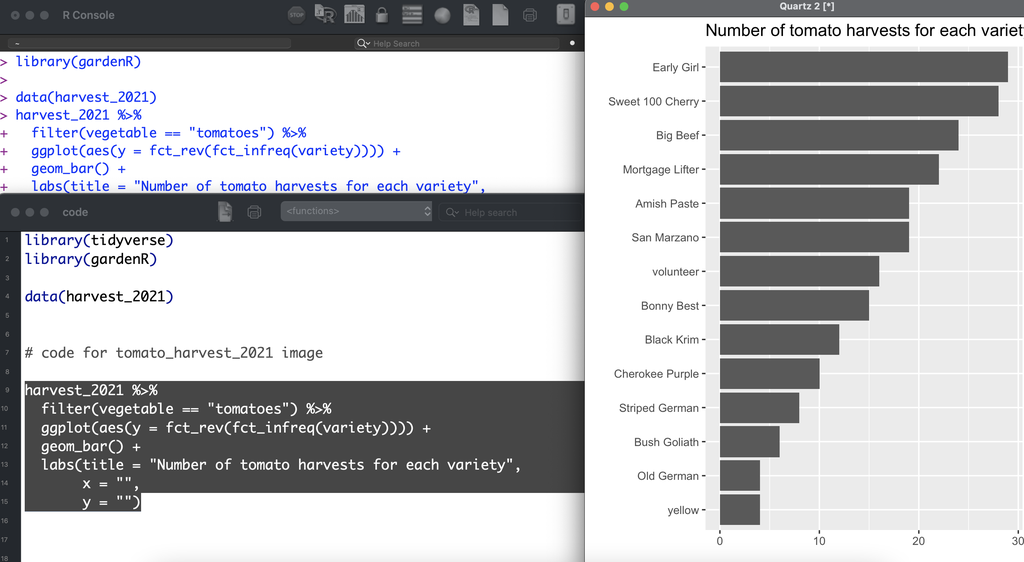

[interactive chart not shown]

[via GIPHY](https://giphy.com/gifs/trump-consequences-NTur7XlVDUdqM)

## Enter RMarkdown

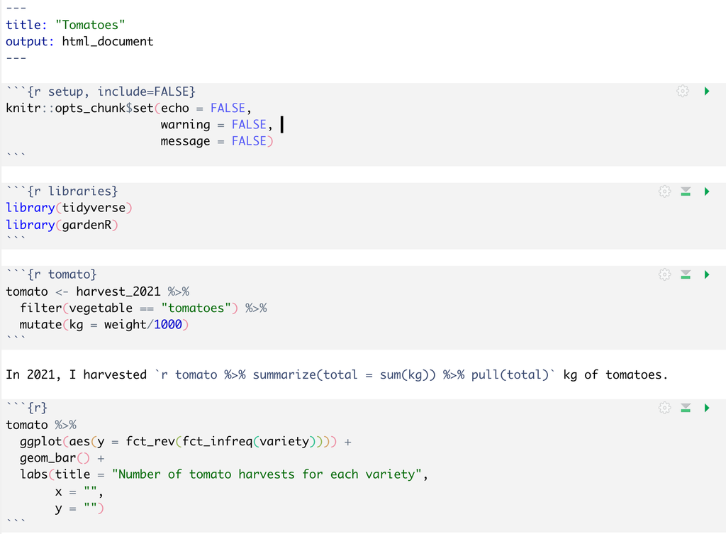

See tomato_example.Rmd

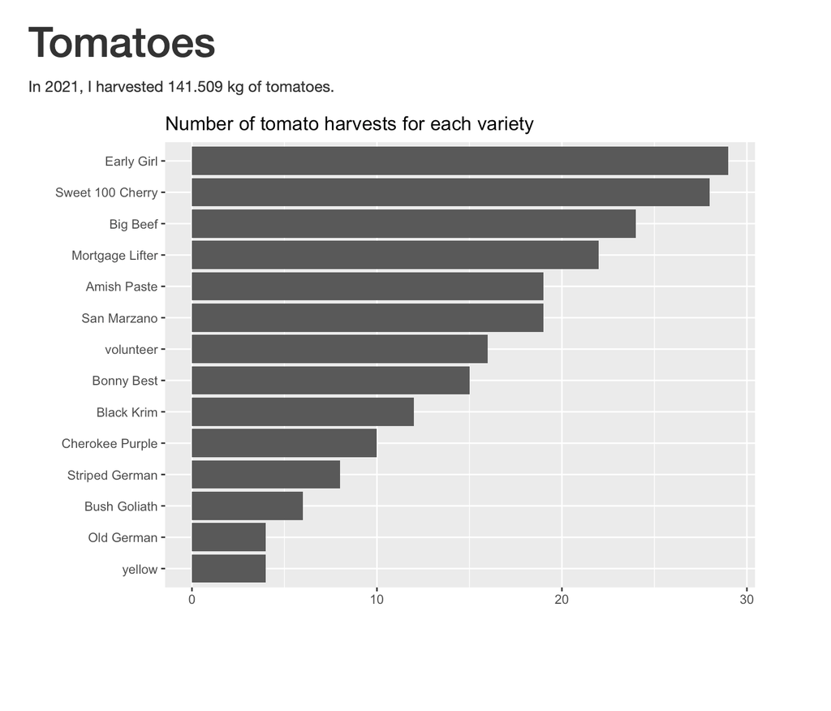

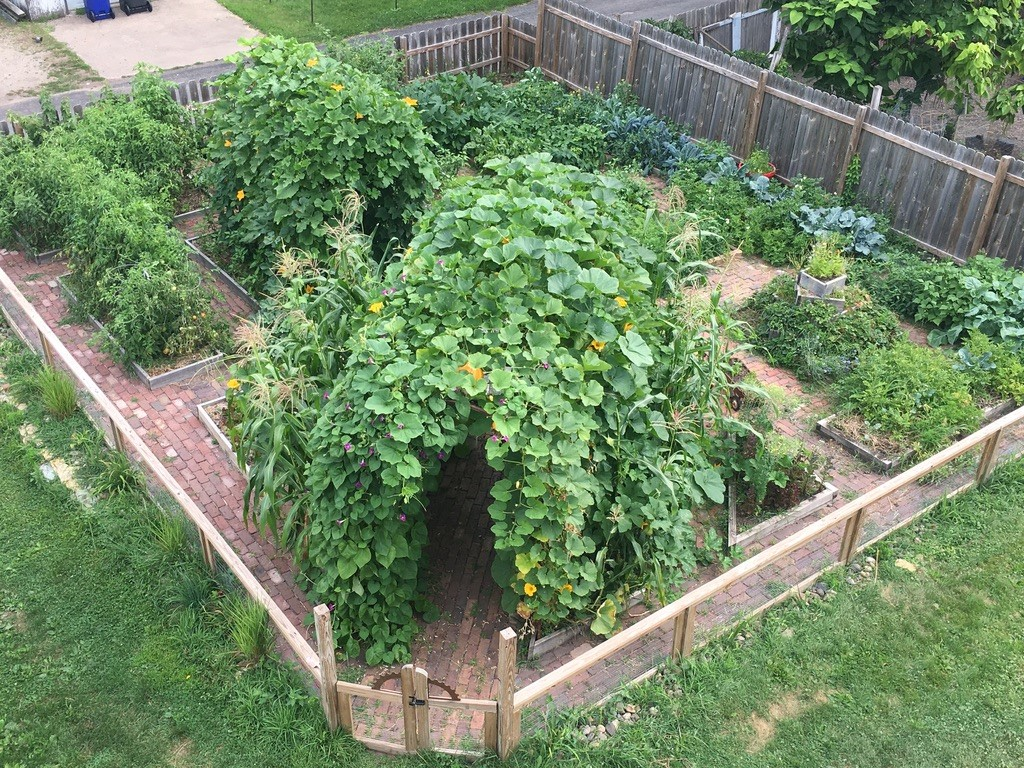

## Goal

Create a report for each vegetable that

- Highlights how its weight compares to other vegetables.
- Shows weights of different varieties of that vegetable.
- Graphs cumulative harvest for that vegetable over time.

Let’s look at the report I created for tomatoes: 01_simple_report.html

[video not shown]

## Now what? … `params`!

See 02_parameterized_report.Rmd for code and the .html file for the report.

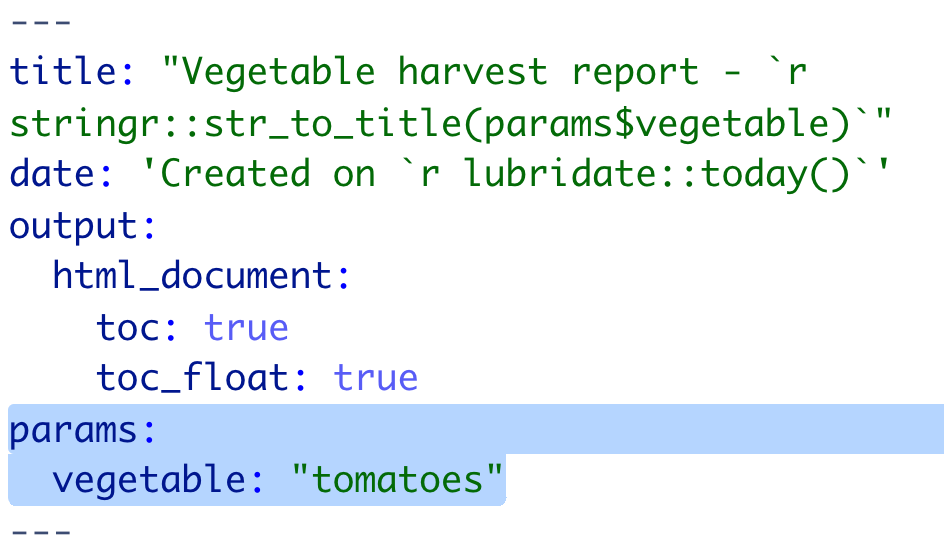

[video not shown]

What you type in Rmd:

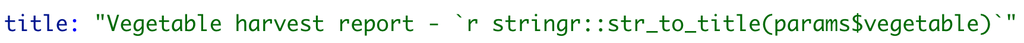

What it looks like in knitted file:

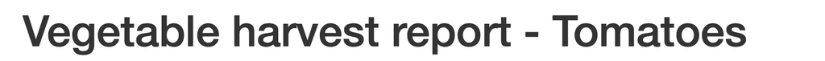

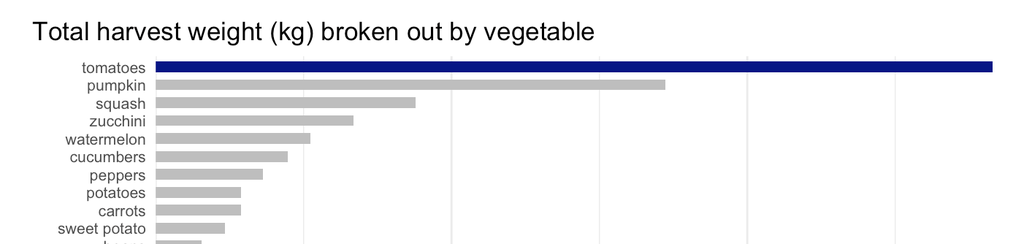

```r
  mutate(veggie_color = vegetable == params$vegetable) %>%
  ggplot(
    aes(x = total_weight_kg,
        y = fct_reorder(vegetable, total_weight_kg),
        fill = veggie_color)
  )
```

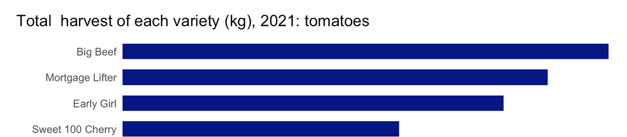

```r
labs(title = paste0("Total  harvest of each variety (kg), 2021: ", params$vegetable)
```

## I want the lettuce report!

[video not shown]

## Change the parameter value - programmatically

See 03_render_reports.R

```r
render(
  # Point to the Rmd file
  input = here("02_parameterized_report.Rmd"),
  # Name the output file (and path)
  # This code puts it in a folder called sample_render
  output_file = here("sample_render", "lettuce_example.html"),
  # New value of parameter
  params = list(vegetable = "lettuce")
  )
```

## Making a lot of reports

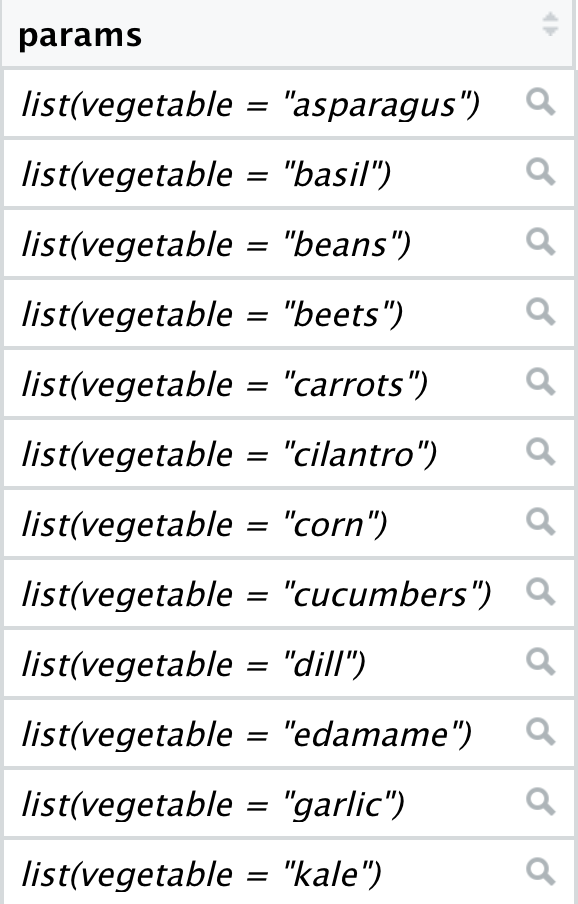

```r
# Vector of all vegetables with more than 2 harvests
veg <- harvest_2021 %>%
  group_by(vegetable) %>%
  summarize(n = n()) %>%
  filter(n > 2) %>%
  pull(vegetable)

# tibble that has the input Rmd, output file path,
# and params written correctly as a list, eg. list(vegetable = "peppers")
reports <- tibble(input = here("02_parameterized_report.Rmd"),
                  output_file = here("output", paste0(veg, "-report.html")),
                  params = map(veg, ~list(vegetable = .)))

# creates all the reports!
reports %>% pwalk(render)
```

## Other examples

- Urban Institute’s [State Fiscal Briefs](https://www.urban.org/policy-centers/cross-center-initiatives/state-and-local-finance-initiative/projects/state-fiscal-briefs)
- North Carolina’s [postsecondary education attainment dashboard](https://dashboard.myfuturenc.org/county-data-and-resources/)
- [Financial report](https://github.com/lindblb/pro_reports_talk/blob/main/finished_reports/fargo_2019_11.pdf) example from Brad Lindblad
- [Real estate data](https://data.ocenime.bg/examples/comparable) (in Bulgarian)
- [Tutorial](https://www.danieldsjoberg.com/dca-tutorial/dca-tutorial-r.html) by Daniel Sjoberg where coding language is a parameter
- R for the Rest of Us’s (David Keyes) Partnership for Strong Communities/Connecticut Data Collaborative [Housing Data Profiles](https://housingprofiles.pschousing.org/)

## Getting started on your own

- R Markdown: The Definitive Guide, [Ch. 15 Parameterized reports](https://bookdown.org/yihui/rmarkdown/parameterized-reports.html)
- Urban Institute [tutorial](https://urban-institute.medium.com/iterated-fact-sheets-with-r-markdown-d685eb4eafce) with David Keyes’ [video](https://rfortherestofus.com/2020/10/parameterized-reporting-with-rmarkdown/)
- Taking it a step further and [creating an API](https://www.datalorax.com/post/power-parameterized-reports-plumber/) by the datalorax (Daniel Anderson)
- Parameterized reporting [using Quarto](https://www.mm218.dev/posts/2022-08-04-how-to-use-quarto-for-parameterized-reporting/) by Mike Mahoney.

## Thank you!

The slides and other files I referenced on the slides are on my github page: https://github.com/llendway/parameterized_reporting_canssi